# Sesión 6: Muestreo y Teorema del límite central

# Introducción y objetivos

Los resistores utilizados en la fabricación de productos electrónicos están etiquetados con una resistencia “nominal” y con un porcentaje de tolerancia. Por ejemplo, se prevee que una resistencia de 330 ohmios (Ω) con una tolerancia del 5% tendrá una resistencia real R entre 313.5 (Ω) y 346.5 (Ω) uniformemente distribuida.

Al finalizar esta sesión, el alumno ha de ser capaz de:

• Entender el comportamiento de la suma y/o promedio de una muestra aleatoria • Comprender el teorema del límite central y sus aplicaciones • Simular una muestra aleatoria y representar los resultados mediante R

# Muestreo

## Muestra aleatoria

Una muestra aleatoria es un conjunto de valores independientes e idénticamente distribuidos, obtenidos a partir de una variable aleatoria X.

**Ejemplo 1:** La resistencia real de resistores etiquetados como 330Ω se distribuye uniformemente entre 313.5Ω y 346.5Ω. Por lo tanto, μR=330 y σR²=90.75.

**Ejemplo 2:** El tiempo que un paciente pasa en cirugía ambulatoria sigue una distribución normal con media 4.5h y desviación típica 1.4h. Por lo tanto: μW=4.5 y σW²=1.96.

Simulemos una muestra para cada ejemplo:

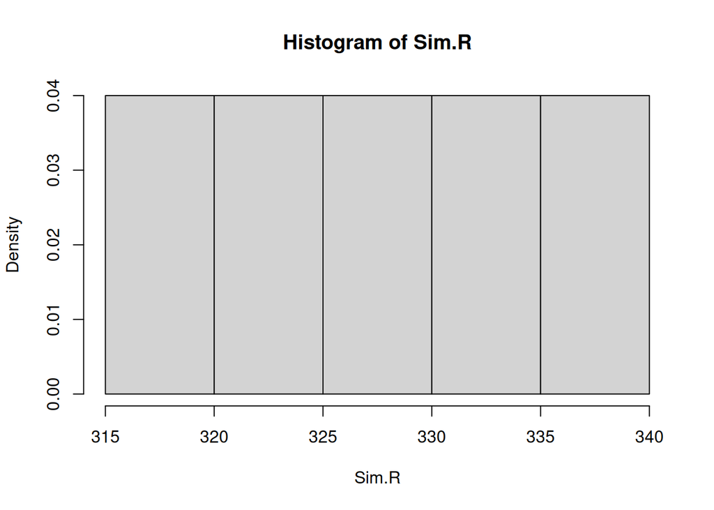

```r
# Ejemplo 1: Resistencias
n.R = 5  # Tamaño de la muestra
set.seed(10)
Sim.R = runif(n.R, min=313.5, max=346.5)
hist(Sim.R, prob=TRUE)
```

```r
mean.R = mean(Sim.R)
var.R = var(Sim.R)
print(c("Media:", mean.R, "Varianza:", var.R))
```

```
## [1] "Media:"           "326.82799000782"  "Varianza:"        "56.0673481677746"
```

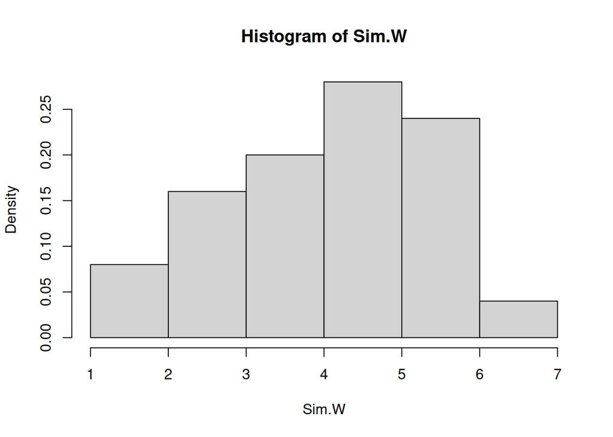

```r
# Ejemplo 2: Tiempos de cirugía
n.W = 25
set.seed(10)
Sim.W = rnorm(n.W, mean=4.5, sd=1.4)
hist(Sim.W, prob=TRUE)
```

```r
mean.W = mean(Sim.W)
var.W = var(Sim.W)
print(c("Media:", mean.W, "Varianza:", var.W))
```

```
## [1] "Media:"           "4.04912294372004" "Varianza:"        "1.74074104403854"
```

## Distribución de la suma muestral

Sea X₁, X₂,…, Xₙ una muestra aleatoria de tamaño n de una población X. La suma T=X₁+X₂+…+Xₙ tiene:

- Valor esperado: E(T) = nμX
- Varianza: V(T) = nσX²
- Si X es normal, entonces T también es normal

Veamos esto con nuestros ejemplos:

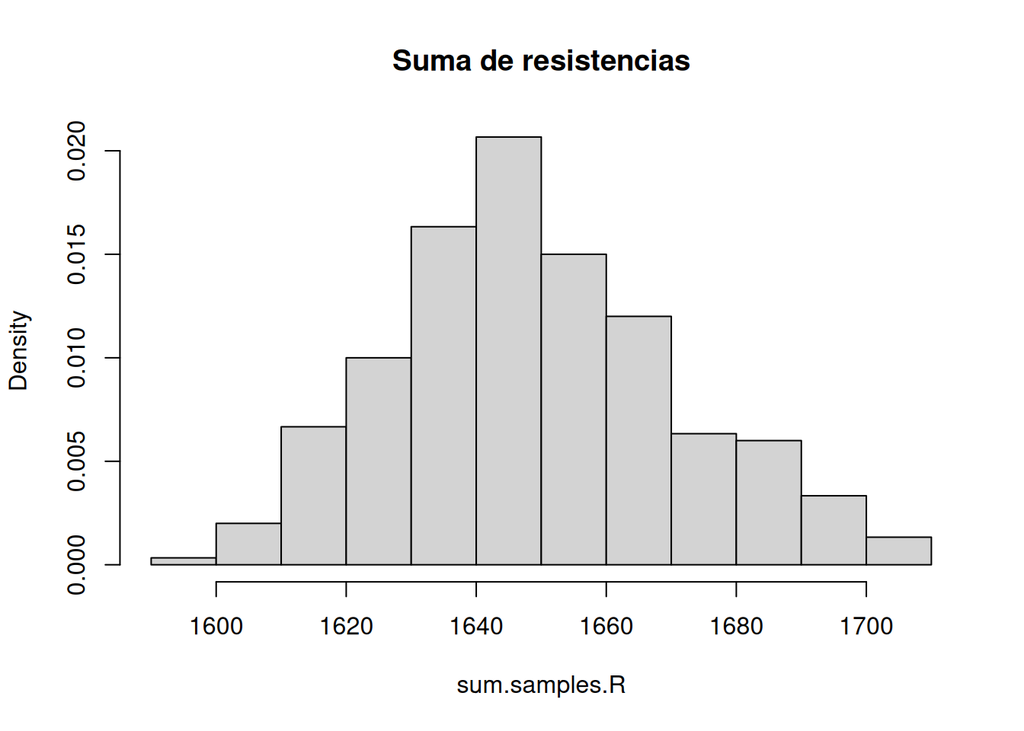

```r
# Simulación de múltiples muestras
N = 300 # Número de muestras

# Ejemplo 1: Resistencias
samples.R = matrix(runif(N*n.R, min=313.5, max=346.5), ncol=n.R)
sum.samples.R = rowSums(samples.R)
hist(sum.samples.R, prob=TRUE, main="Suma de resistencias")
```

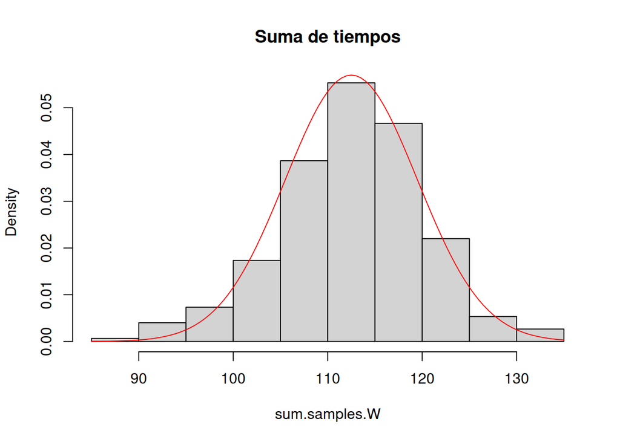

```r
# Ejemplo 2: Tiempos
samples.W = matrix(rnorm(N*n.W, mean=4.5, sd=1.4), ncol=n.W)
sum.samples.W = rowSums(samples.W)
hist(sum.samples.W, prob=TRUE, main="Suma de tiempos")
curve(dnorm(x, mean=n.W*4.5, sd=sqrt(n.W)*1.4), add=TRUE, col="red")
```

## Distribución de la media muestral

La media muestral X̄=(X₁+X₂+…+Xₙ)/n tiene:

- Valor esperado: E(X̄) = μX
- Varianza: V(X̄) = σX²/n
- Si X es normal, entonces X̄ también es normal

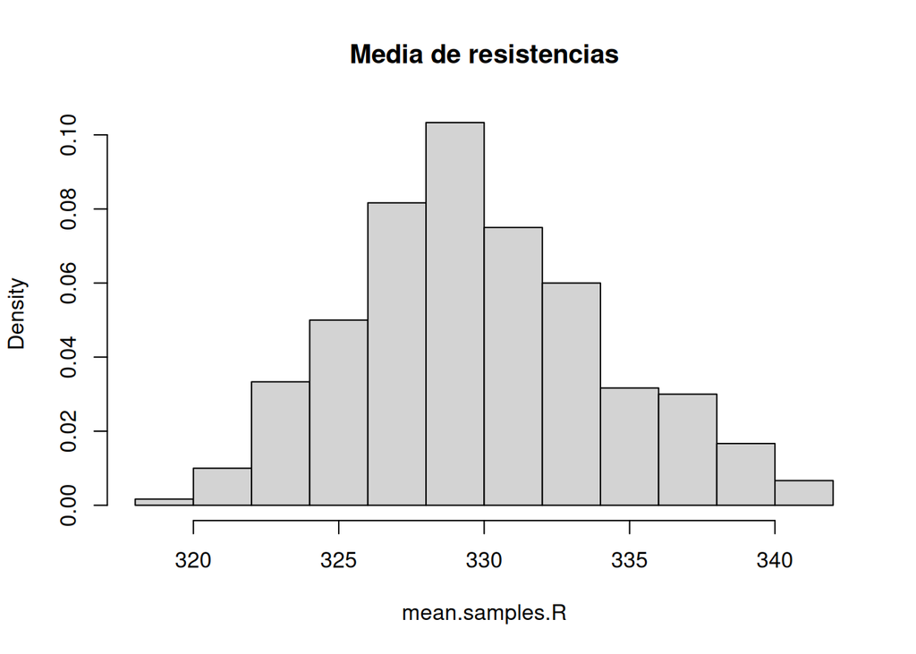

```r
# Ejemplo 1: Resistencias
mean.samples.R = rowMeans(samples.R)
hist(mean.samples.R, prob=TRUE, main="Media de resistencias")
```

```r
print(c("Media de medias:", mean(mean.samples.R),
        "Varianza de medias:", var(mean.samples.R)))
```

```
## [1] "Media de medias:"    "329.849837744888"    "Varianza de medias:"
## [4] "19.1233118104333"
```

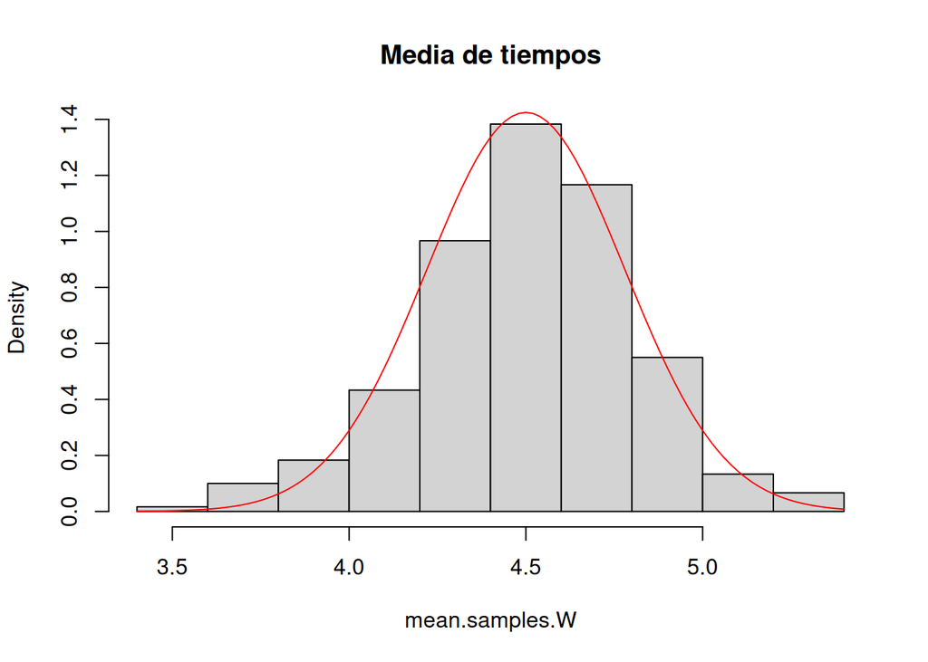

```r
# Ejemplo 2: Tiempos
mean.samples.W = rowMeans(samples.W)
hist(mean.samples.W, prob=TRUE, main="Media de tiempos")
curve(dnorm(x, mean=4.5, sd=1.4/sqrt(n.W)), add=TRUE, col="red")
```

```r
print(c("Media de medias:", mean(mean.samples.W),
        "Varianza de medias:", var(mean.samples.W)))
```

```
## [1] "Media de medias:"    "4.50313087417086"    "Varianza de medias:"
## [4] "0.0935498794881019"
```

## Distribución de la varianza muestral

La varianza muestral S²=Σ(Xᵢ-X̄)²/(n-1) tiene:

- Valor esperado: E(S²) = σX²
- Cuando n→∞, V(S²)→0
- Si X es normal, entonces (n-1)S²/σX² sigue una distribución χ² con n-1 grados de libertad

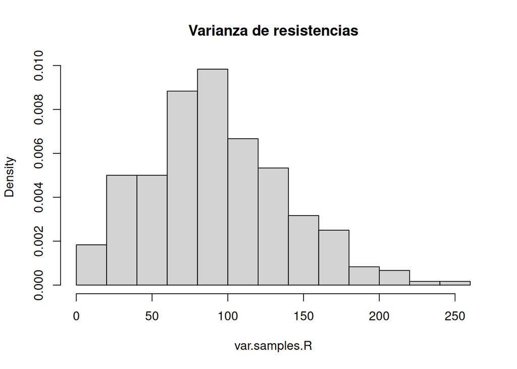

```r
# Ejemplo 1: Resistencias
var.samples.R = apply(samples.R, 1, var)
hist(var.samples.R, prob=TRUE, main="Varianza de resistencias")
```

```r
print(c("Media de varianzas:", mean(var.samples.R)))
```

```
## [1] "Media de varianzas:" "92.4632105170479"
```

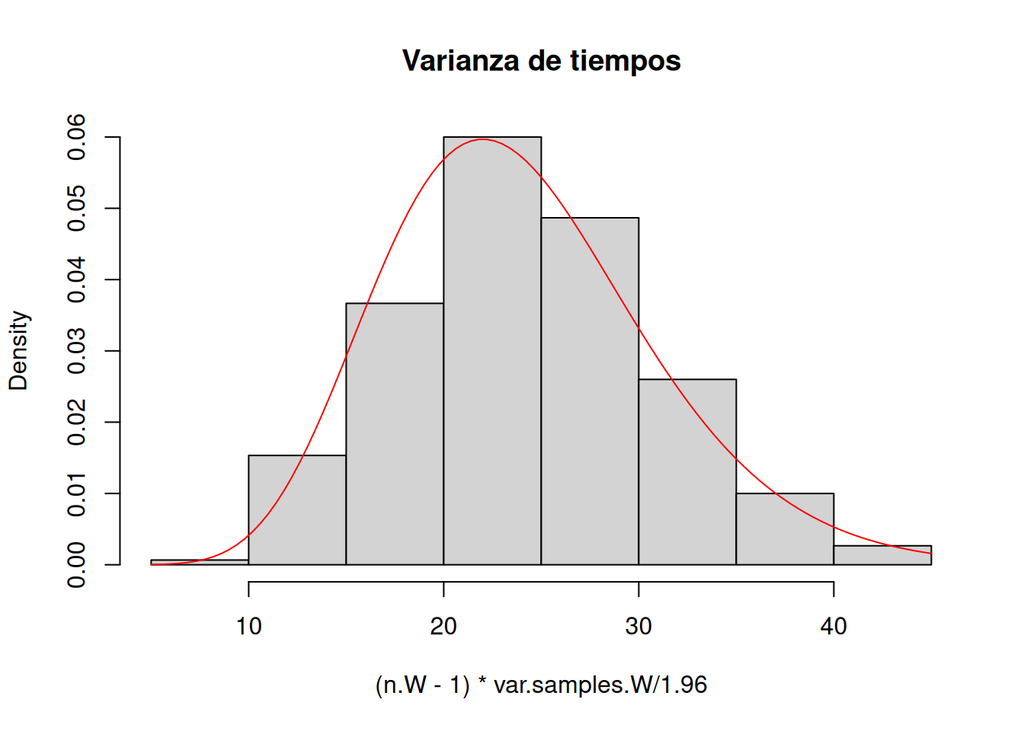

```r
# Ejemplo 2: Tiempos
var.samples.W = apply(samples.W, 1, var)
hist((n.W-1)*var.samples.W/1.96, prob=TRUE, main="Varianza de tiempos")
curve(dchisq(x, df=n.W-1), add=TRUE, col="red")
```

```r
print(c("Media de varianzas:", mean(var.samples.W)))
```

```
## [1] "Media de varianzas:" "1.97501540363167"
```

# Teorema del límite central

El teorema del límite central es uno de los resultados más importantes de la estadística. Establece que para una muestra aleatoria suficientemente grande, la distribución de la media muestral se aproxima a una distribución normal, independientemente de la distribución de la población original.

Formalmente, sea X₁, X₂, X₃, …, Xₙ un conjunto de n variables aleatorias independientes e idénticamente distribuidas con media μ y varianza σ² finita. Sea su suma Tₙ = X₁+X₂+X₃+…+Xₙ, entonces:

$$\lim_{n\to \infty}
P\left(\frac{T_n-n\mu}{\sigma\sqrt{n}}\leq z\right) = \Phi
(z)$$

donde Φ(z) es la función de distribución de la normal estándar N(0,1).

En términos de la media muestral X̄ = Tₙ/n, esto implica que:

$$\frac{\bar{X}-\mu}{\sigma/\sqrt{n}}
\xrightarrow{d} N(0,1)$$

Es decir, para n suficientemente grande:

$$\bar{X} \sim N\left(\mu,
\frac{\sigma^2}{n}\right)$$

Algunas consideraciones importantes:

1. El teorema se cumple independientemente de la distribución original de la población
2. La aproximación mejora conforme aumenta n
3. Si la población original es normal, la distribución de X̄ es exactamente normal para cualquier n
4. Para poblaciones no normales, se considera que n ≥ 30 es suficientemente grande para una buena aproximación

Veamos esto con el ejemplo de las resistencias, que originalmente tiene distribución uniforme:

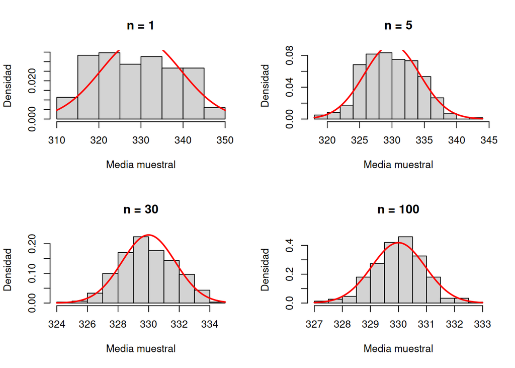

```r
# Diferentes tamaños de muestra
n.sizes = c(1, 5, 30, 100)
par(mfrow=c(2,2))

for(n in n.sizes) {
  samples = matrix(runif(N*n, min=313.5, max=346.5), ncol=n)
  means = rowMeans(samples)
  hist(means, prob=TRUE,
       main=paste("n =", n),
       xlab="Media muestral",
       ylab="Densidad")
  # Añadimos la curva normal teórica
  curve(dnorm(x, mean=330, sd=sqrt(90.75/n)),
        add=TRUE, col="red", lwd=2)
  # Añadimos leyenda con los parámetros
  # legend("topright",
  #        legend=paste("N(330,", round(90.75/n,2), ")"),
  #        col="red", lwd=2, bty="n")
}
```

Observamos que:

1. Para n=1, la distribución es uniforme (igual que la población)
2. Para n=5, la distribución empieza a parecerse a una normal
3. Para n=30, la aproximación a la normal es bastante buena
4. Para n=100, la distribución es prácticamente normal y además su varianza es menor

En el caso de los tiempos de cirugía, como la población original ya es normal, la media muestral es exactamente normal para cualquier n:

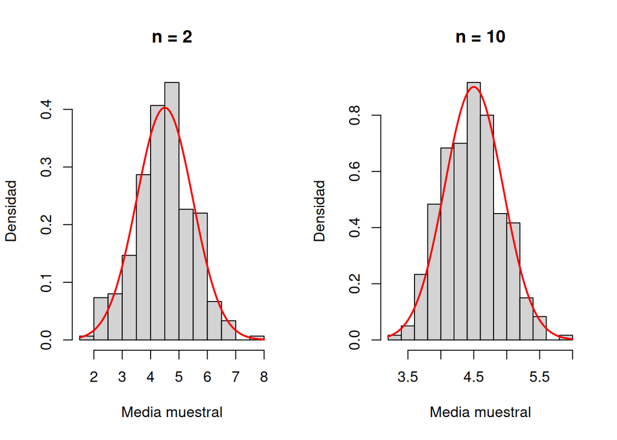

```r
# Comprobación con tiempos de cirugía (distribución original normal)
n.check = c(2, 10)
par(mfrow=c(1,2))

for(n in n.check) {
  samples = matrix(rnorm(N*n, mean=4.5, sd=1.4), ncol=n)
  means = rowMeans(samples)
  hist(means, prob=TRUE,
       main=paste("n =", n),
       xlab="Media muestral",
       ylab="Densidad")
  curve(dnorm(x, mean=4.5, sd=1.4/sqrt(n)),
        add=TRUE, col="red", lwd=2)
  # legend("topright",
  #        legend=paste("N(4.5,", round(1.96/n,3), ")"),
  #        col="red", lwd=2, bty="n")
}
```

Este teorema es fundamental en inferencia estadística ya que nos permite:

1. Aproximar la distribución de la media muestral incluso cuando no conocemos la distribución de la población
2. Construir intervalos de confianza y realizar pruebas de hipótesis sobre la media poblacional
3. Justificar el uso de métodos basados en la normalidad cuando trabajamos con muestras grandes

## Notas Importantes

- Para muestras grandes (n ≥ 30), el TLC se puede aplicar independientemente de la distribución original
- Si la población es normal, todas las distribuciones muestrales son exactas para cualquier n
- La varianza muestral $S^2$ sigue una distribución $\chi^2$ solo si la población es normal
- El argumento MARGIN en apply(): 1=filas, 2=columnas
- Para reproducibilidad, siempre usar set.seed() antes de simulaciones

# Formulario de Muestreo y Teorema del Límite Central

## Estadísticos Muestrales Básicos

| Estadístico | Fórmula | Propiedades |
| --- | --- | --- |
| Media Muestral | $\bar{X}=\frac{1}{n}\sum_{i=1}^n X_i$ | $E(\bar{X})=\mu$ |
| Varianza Muestral | $S^2=\frac{1}{n-1}\sum_{i=1}^n (X_i-\bar{X})^2$ | $E(S^2)=\sigma^2$ |

## Distribución de la Suma Muestral (T)

| Propiedad | Fórmula |
| --- | --- |
| Media | $E(T)=n\mu$ |
| Varianza | $V(T)=n\sigma^2$ |
| Si X es normal | $T \sim N(n\mu,n\sigma^2)$ |

## Distribución de la Media Muestral ($\bar{X}$)

| Propiedad | Fórmula |
| --- | --- |
| Media | $E(\bar{X})=\mu$ |
| Varianza | $V(\bar{X})=\frac{\sigma^2}{n}$ |
| Si X es normal | $\bar{X} \sim N(\mu,\frac{\sigma^2}{n})$ |

## Distribución de la Varianza Muestral ($S^2$)

| Propiedad | Fórmula |
| --- | --- |
| Media | $E(S^2)=\sigma^2$ |
| Si X es normal | $(n-1)\frac{S^2}{\sigma^2} \sim \chi^2_{n-1}$ |

## Teorema del Límite Central

| Caso | Resultado |
| --- | --- |
| Para n grande | $\bar{X} \xrightarrow{d} N(\mu,\frac{\sigma^2}{n})$ |
| Suma estandarizada | $\frac{T-n\mu}{\sigma\sqrt{n}} \xrightarrow{d} N(0,1)$ |
| Media estandarizada | $\frac{\bar{X}-\mu}{\sigma/\sqrt{n}} \xrightarrow{d} N(0,1)$ |

## Probabilidades Importantes

| Tipo | Fórmula |
| --- | --- |
| P(a < T < b) | $P(a < T < b) = \Phi(\frac{b-n\mu}{\sqrt{n}\sigma}) - \Phi(\frac{a-n\mu}{\sqrt{n}\sigma})$ |
| P(a < $\bar{X}$ < b) | $P(a < \bar{X} < b) = \Phi(\frac{b-\mu}{\sigma/\sqrt{n}}) - \Phi(\frac{a-\mu}{\sigma/\sqrt{n}})$ |
| P(a < $S^2$ < b) | $P(a < S^2 < b) = P(\frac{(n-1)a}{\sigma^2} < \chi^2_{n-1} < \frac{(n-1)b}{\sigma^2})$ |

## Comandos R Importantes

| Comando | Descripción | Ejemplo |
| --- | --- | --- |
| `set.seed()` | Fija semilla para reproducibilidad | `set.seed(321)` |
| `sample()` | Muestreo aleatorio | `sample(x, size, replace=TRUE, prob=NULL)` |
| `apply()` | Aplica función por filas/columnas | `apply(X, MARGIN, FUN)` |
| `matrix()` | Crea matriz | `matrix(data, nrow, ncol)` |
| `rnorm()` | Genera números aleatorios normales | `rnorm(n, mean, sd)` |
| `runif()` | Genera números aleatorios uniformes | `runif(n, min, max)` |
| `pnorm()` | Probabilidad acumulada normal | `pnorm(q, mean, sd)` |
| `pchisq()` | Probabilidad acumulada chi-cuadrado | `pchisq(q, df)` |
| `hist()` | Crea histograma | `hist(x, prob=TRUE)` |
| `curve()` | Añade curva a gráfico | `curve(dnorm(x,mean,sd), add=TRUE)` |

## Funciones Útiles para Muestreo en R

| Operación | Código R |
| --- | --- |
| Media de una muestra | `mean(x)` |
| Varianza de una muestra | `var(x)` |
| Suma por filas | `apply(X, 1, sum)` o `rowSums(X)` |
| Media por filas | `apply(X, 1, mean)` o `rowMeans(X)` |
| Varianza por filas | `apply(X, 1, var)` |
| Simulación de N muestras tamaño n | `matrix(rnorm(N*n, mean, sd), ncol=n)` |
| Histograma con curva normal | `hist(x, prob=TRUE) curve(dnorm(x,mean,sd), add=TRUE)` |